# Phys474_S23_Hwk4

Physics 474 - Spring 2023

Homework 4 - Solving PDE and ODE boundary value problems with the relaxation method

Using the Gauss-Seidel overrelaxation method

Author: Djamil Lakhdar-Hamina

In this problem we will solving for the electric potential $\phi(\vec{r})$ and electric field $\vec{E}(x,y)$ in a cylindrical configuration, similar to a coax cable, with fixed voltages on the inner conductor and outer conductor. See figure.

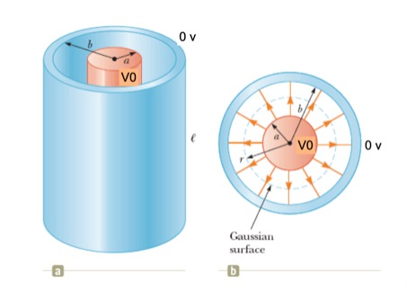

Part a: (10 points)

Poisson's equation in 2-D for electric potential $\phi$ in empty space with boundry conditions.

$\nabla^2 \phi(x,y) = 0$

or,

$\frac{\partial^2 \phi(x,y)}{\partial x ^2}+\frac{\partial^2 \phi(x,y)}{\partial y ^2}=0$

From our lecture we saw that we can use a space-centered finite difference method with grid spacing $a$ for second partial derivatives that yields the approximation

$\Large \nabla^2 \phi(x,y)\approx \frac{\phi(x+a,t)+\phi(x-a,t)-2\phi(x,t)}{a^2} + \frac{\phi(y+a,t)+\phi(y-a,t)-2\phi(y,t)}{a^2}$

Setting this equal to zero for the Poisson equation we get

$\phi(x+a,y)+\phi(x-a,y)+\phi(x,y+a)+\phi(x,y-a)-4\phi(x,y)=0$

or

$\phi(x,y) = \frac{1}{4}\left[\phi(x+a,y)+\phi(x-a,y)+\phi(x,y+a)+\phi(x,y-a)\right]$

These are a set of $n \times n$ simulataneous which could be solved holding the boundary boints at their fixed values.

we will use an iterative method that we call **The Relaxation Method** to solve this set of equations

We will use the **Gauss-Seidel overrelaxation method (see lecture and examples)**

- Fix $\phi(x,y)$ at boundaries for every iteration
- guess some initial values for $\phi(x,y)$
- apply GS-Overrelaxation equation with weight $w<1.0$ to update values on all grid points $\phi(x,y) \leftarrow \frac{(1+w)}{4}\left[\phi(x+a,y)+\phi(x-a,y)+\phi(x,y+a)+\phi(x,y-a)\right]-w \phi(x,y)$
- NOTE: The array on the left is the same as on the right in the implementation, that is the Gauss-Seidel part.
- take these new values and feed them back into right hand side
- Calculate another new set of values, again and again and …
- Until $\phi(x,y)$ settles down (i.e. relaxes) to a fixed value. That is the solution!

The parameters of the coax are:

- radius of the inner conductor is $a = 1\,mm$
- radius of the outer conductor is $b = 6\,mm$
- electric potential (i.e. voltage) on the inner conductor is $V0 = 100 \, v$
- electric potential on the outer conductor is $0 \, v$

for the Gauss-Seidel overrelaxation method use:

- overrelaxation weighting factor $w=0.92$
- termination when max difference between iterations is 1e-8 or iterations = 2500
- pick a 2D grid from $-7$ mm to $+7$ mm for both $x,y$
- use (2n+1)x(2n+1) grid points so the center point is at 0 and it is symmetric on either side (start with n=50)
- investigate different n (maybe 25 and 100)

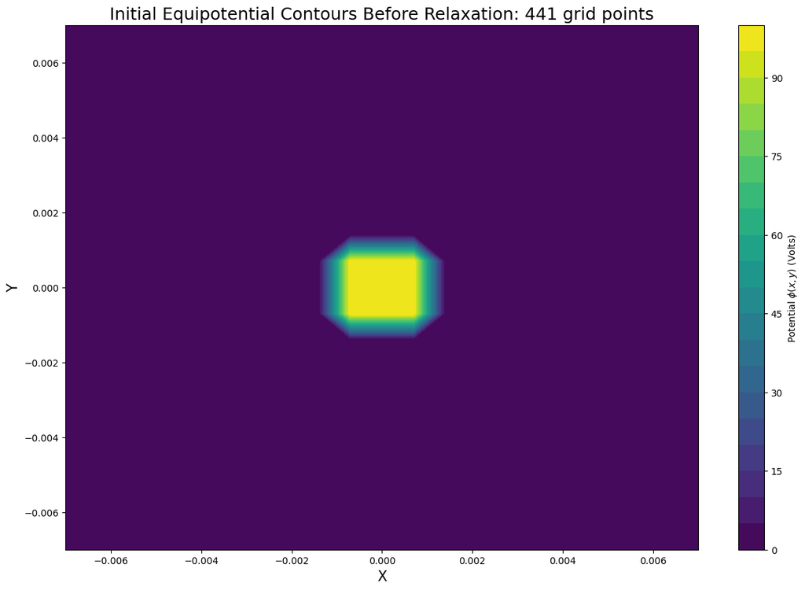

```
Execution time for 441 grid points : 0.6668 seconds
```

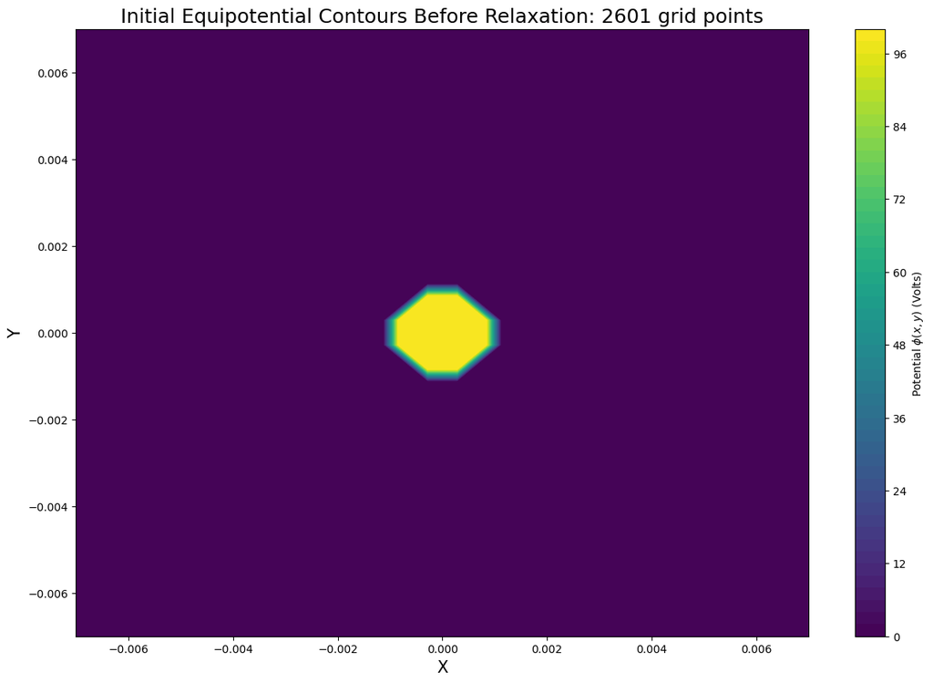

```
Execution time for 2601 grid points : 1.9149 seconds
```

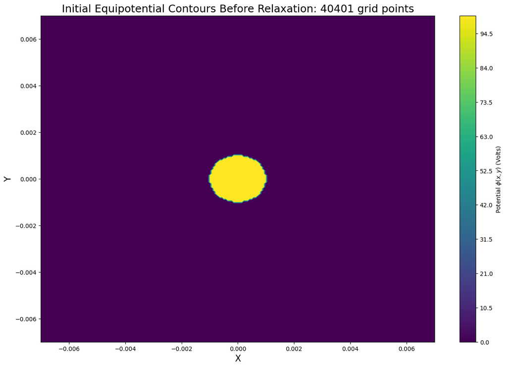

```
Execution time for 40401 grid points : 78.1732 seconds
```

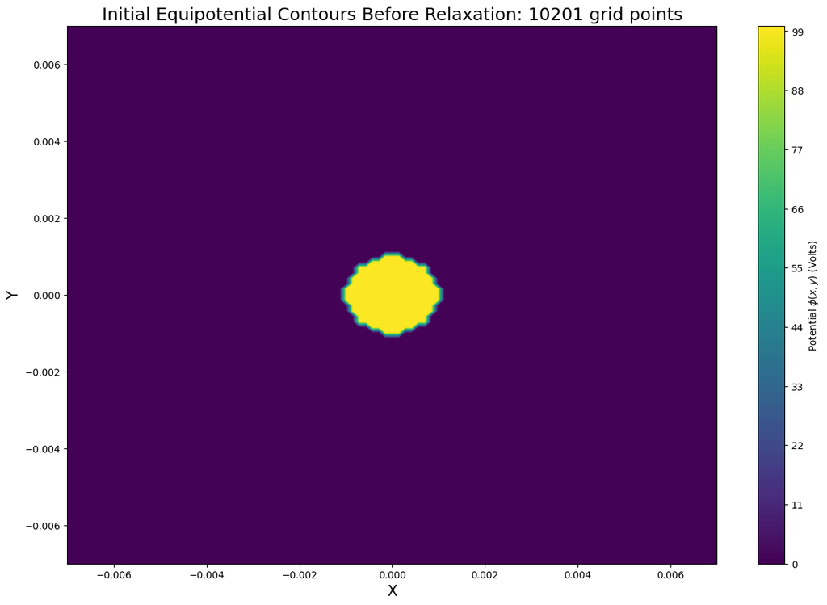

```
Execution time for 10201 grid points : 7.6083 seconds
```

```python
import numpy as np
import matplotlib.pyplot as plt
import copy
import time


sqrt=lambda x : x**(1/2)
w=.92
N=100
max_iterations=2500
threshold=1e-8
xmin=-.007
xmax=.007
ymax,ymin=xmax,xmin
left_x=[0,.0001,.0005,.0008,.001]
left_y=[100,100,100,100,100]
right_x=[.006,.007,.008]
right_y=[0,0,0]

a=.001
b=.006
V0=100
phi=lambda x,a,b,V0:V0*np.log(x/b)/np.log(a/b)
e_field=lambda V0, x,a,b: (V0/x)*(1/-np.log(a/b))


def initialize_grid(xmin,xmax,ymin,ymax,X,Y,inner_r,outer_r,phi)->[[(float,int)]]:

    """


    """

    grid=[]
    ground=0
    flag=1
    for y in Y:
        row=[]
        for x in X:
            if np.sqrt(x**2+y**2)<=inner_r:
                    row.append([phi,flag])
            elif np.sqrt(x**2+y**2)>inner_r:
                if np.sqrt(x**2+y**2)>=outer_r:
                    row.append([ground,flag])
                else:
                    row.append([ground,flag-1])
        grid.append(row)
    return grid



def overrelax(N,grid,threshold,w) -> None:
    """

    """

    potential_index = 0
    flag_index = 1
    diff_iteration = 1
    iterator = 0

    while iterator < max_iterations:

        prev_grid = copy.deepcopy(grid)
        diffs = []
        for i in range(0, N- 1):
            for j in range(0, N - 1):
                if grid[i][j][flag_index] == flag_index - 1:
                    grid[i][j][potential_index] = (1 + w) / 4 * (
                            grid[i + 1][j][potential_index] + grid[i - 1][j][potential_index] + grid[i][j + 1][
                        potential_index] + grid[i][j - 1][potential_index]) - w * grid[i][j][potential_index]
                    diffs.append(grid[i][j][potential_index] - prev_grid[i][j][potential_index])
                else:
                    pass

        if max(diffs) <= threshold:
            break

        iterator += 1



def extract_potential(grid,x,y):

    """



    """
    potential_index=0
    potentials=[]
    for i in range(0,len(x)):
        row=[]
        for j in range(0, len(y)):
            row.append(grid[i][j][potential_index])
        potentials.append(row)

    return potentials


## investigating different N
for n in [10,25,100,50]:

    N=2*n+1
    x=np.linspace(xmin,xmax,N)
    y=np.linspace(ymin,ymax,N)
    X,Y=np.meshgrid(x,y)
    spacing=x[1]-y[0]
    tic = time.perf_counter()
    grid=initialize_grid(xmin,xmax,ymin,ymax,x,y,a,b,V0)
    potentials=extract_potential(grid,x,y)
    plt.figure(figsize=(15,10))
    plt.contourf(X,Y,potentials,N)
    plt.colorbar(label='Potential $\phi(x,y)$ (Volts) ')  # put in colorbar for contourf
    plt.xlabel('X',fontsize=15)
    plt.ylabel('Y',size=15)
    # plt.grid('--')
    plt.title(f'Initial Equipotential Contours Before Relaxation: {N*N} grid points',size=18)
    plt.show()
    overrelax(N,grid,threshold,w)
    toc = time.perf_counter()
    print(f"Execution time for {N*N} grid points : {toc - tic:0.4f} seconds")
```

Part b: (5 points)

- Plot the equipotential contours using 'contourf' and showing a colorbar
- Calculate (using numpy gradient) and Plot (using matplotlib quiver) the Electric field $\vec{E}$
- You may want to skip every some number of points for quiver...

where,

$\vec{E} = -\nabla \phi = -\left(\frac{\partial \phi(x,y)}{\partial x }\hat{x}+\frac{\partial \phi(x,y)}{\partial y }\hat{y}\right)$

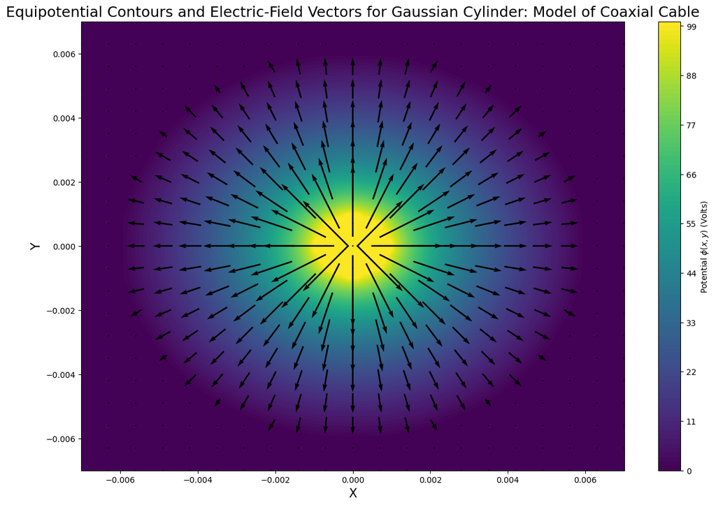

```python
potentials=extract_potential(grid,x,y)
plt.figure(figsize=(15,10))
plt.contourf(X,Y,potentials,N)
plt.colorbar(label='Potential $\phi(x,y)$ (Volts) ')  # put in colorbar for contourf
plt.xlabel('X',fontsize=15)
plt.ylabel('Y',size=15)
# plt.grid('--')
plt.title(r'Equipotential Contours and Electric-Field Vectors for Gaussian Cylinder: Model of Coaxial Cable',size=18)

E_field=np.negative(np.gradient(potentials,spacing))

E_y,E_x=E_field[0],E_field[1]

plt.quiver(X[::5,::5],Y[::5,::5],E_x[::5,::5],E_y[::5,::5],pivot='mid')
```

Part c: (5 points)

In this part we are going to examine the accuracy of the solution.

This problem has a simple analytic solution. Due to the nature of the cylindrical symmetry we can use Gauss' Law to calculate the Electric field, which is radial only, and the work-energy theorem to calculate the potential that is only a function of the radius $r$.

The solutions are:

for $a < r < b$

$\large \phi = \phi(r) = V0 \, \frac{log(r/b)}{log(a/b)}$

$\large \vec{E}= \frac{V0}{r} \frac{\hat{r}}{-log(a/b)}$

for $r \leq a$

$\phi = V0$ and $\vec{E}=0$

for $r \geq b$

$\phi = 0$ and $\vec{E}=0$

Since there is radial symmetry we will compare the numeric solution to the analytic solution along the positive x-axis only.

1. Figure 1: Plot the two solutions for the potential $\phi$ vs x for $0\leq x \leq 0.007$
2. Figure 2: Make a plot with 2 subplots a) both potentials $\phi$ and b) difference in potentials vs x for $a <x < b$
3. Figure 3: Make a plot with 2 subplots a) both $|\vec{E}|$ and b) difference in $|\vec{E}|$ vs x for $a <x < b$

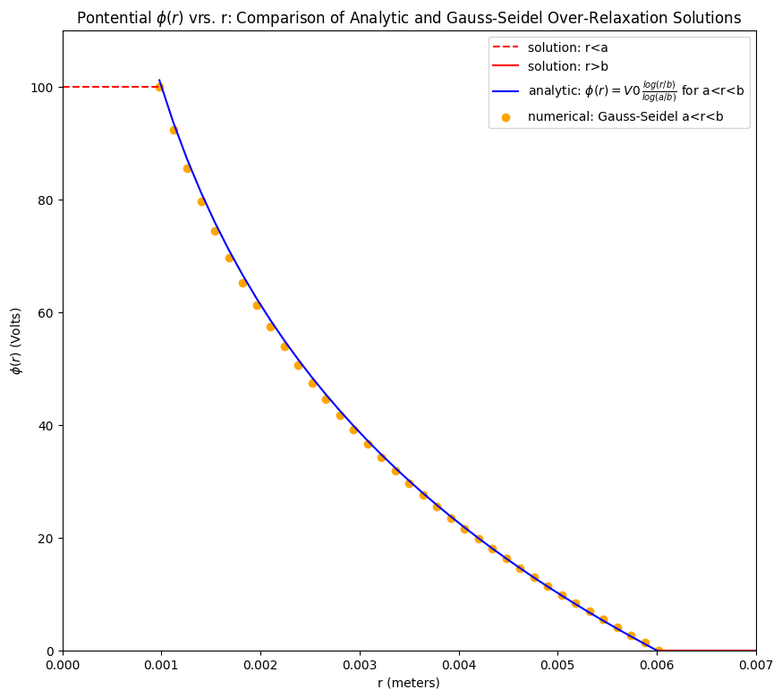

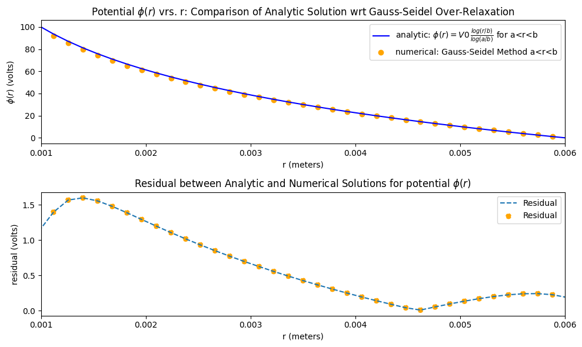

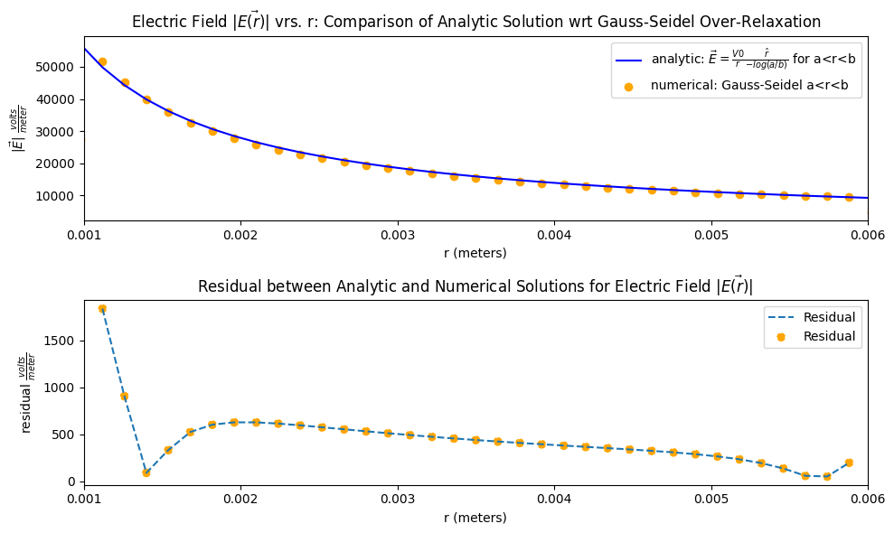

```python
## figure 1
# x_analytic=np.linspace(a,b,2*N+1)
N=50
x=X[N][N+7:2*N-6]
potential_x=potentials[N][N+7:2*N-6]
e_x_axis=E_x[N][N+7:2*N-6]
y_analytic=phi(x,a,b,V0)
analytic_e=e_field(V0,x,a,b)

plt.figure(figsize=(10,9))
plt.plot(left_x,left_y,color='red',linestyle='--',label='solution: r<a')
plt.plot(right_x,right_y,color='red',linestyle='-',label='solution: r>b')
plt.plot(x,y_analytic,label=r'analytic: $\phi(r)=V0\, \frac{log(r/b)}{log(a/b)}$ for a<r<b',color='blue')
plt.scatter(x,potential_x,label='numerical: Gauss-Seidel a<r<b',color='orange')
plt.xlim((0,.007))

plt.ylim((0,110))
plt.xlabel('r (meters)')
plt.ylabel('$\phi(r)$ (Volts)')
plt.title('Pontential $\phi(r)$ vrs. r: Comparison of Analytic and Gauss-Seidel Over-Relaxation Solutions')
plt.legend()
plt.show()

## figure 2
fig,axs=plt.subplots(2,figsize=(10,6))

axs[0].set_title('Potential $\phi(r)$ vrs. r: Comparison of Analytic Solution wrt Gauss-Seidel Over-Relaxation')
axs[0].set_xlabel('r (meters)')
axs[0].set_ylabel('$\phi(r)$ (volts)')
axs[0].plot(x,y_analytic,label=r'analytic: $\phi(r)=V0\, \frac{log(r/b)}{log(a/b)}$ for a<r<b',color='blue')
axs[0].scatter(x,potential_x,label='numerical: Gauss-Seidel Method a<r<b',color='orange')
axs[0].legend(fancybox=True,shadow=False)
axs[0].set_xlim((.001,.006))

# axs[1].plot(x_analytic[8:],y_analytic[6:]-potentials[N][N+7:])

axs[1].set_title(r'Residual between Analytic and Numerical Solutions for potential $\phi(r)$ ')
axs[1].set_xlabel('r (meters)')
axs[1].set_ylabel('residual (volts)')
axs[1].plot(x,np.absolute(potential_x-y_analytic),label='Residual',linestyle='--')
axs[1].scatter(x,np.absolute(potential_x-y_analytic),label='Residual',linestyle='--',color='orange')

axs[1].set_xlim((.001,.006))
axs[1].legend()
fig.tight_layout()

## figure 3

##

fig,axs=plt.subplots(2,figsize=(10,6))

axs[0].set_title(r'Electric Field $|\vec{E(r)}|$ vrs. r: Comparison of Analytic Solution wrt Gauss-Seidel Over-Relaxation')
axs[0].set_xlabel('r (meters)')
axs[0].set_ylabel(r'$|\vec{E}|$ $\frac{volts}{meter}$')
axs[0].plot(x,analytic_e,label=r'analytic: $ \vec{E}= \frac{V0}{r} \frac{\hat{r}}{-log(a/b)}$ for a<r<b',color='blue')
axs[0].scatter(x,e_x_axis,label='numerical: Gauss-Seidel a<r<b',color='orange')
axs[0].legend(fancybox=True,shadow=False)
axs[0].set_xlim((.001,.006))

# axs[1].plot(x_analytic[8:],y_analytic[6:]-potentials[N][N+7:])


axs[1].set_title(r'Residual between Analytic and Numerical Solutions for Electric Field $|\vec{E(r)}|$ ')
axs[1].set_xlabel('r (meters)')
axs[1].set_ylabel(r'residual $\frac{volts}{meter}$')
axs[1].plot(x[1:-1],np.absolute(analytic_e[1:-1]-e_x_axis[1:-1]),label='Residual',linestyle='--')
axs[1].scatter(x[1:-1],np.absolute(analytic_e[1:-1]-e_x_axis[1:-1]),label='Residual',linestyle='--',color='orange')

axs[1].set_xlim((.001,.006))
axs[1].legend()

fig.tight_layout()
```

Observations and Summary

For the following analyses, we fixed our grid number at 10201, N=50. The potential contour plot revealed that the potential seemed to decrease from the inner inner boundary to the outer. The electric field was radial, as was expected by cylindrical symmetry, and also seemed to decrease as the distance from the inner boundary increased, although the relationship was not clear by the potential and electric field. To clarify that relationship we did further graphical analysis.

In comparing the analytic and numerical solutions we found that the solutions were close. First off, for the regime a<x<b, the numerical and analytic solutions for potential had similar forms. The residuals between analytic and numerical potentials were slight, and seemed to have a strange almost sinusoidal character. The residuals however were peaked near the inner boundary around r=.001, then seemed to decrease until near the outer boundary at r=.006. The electric field graph also showed close resemblance in form between analytic and numerical solutions. The residuals relative to the values were slight, however there seemed to be a sort of discontinuity in residual in the regime near r=.001, a sharp decrease then rise, before a levelling and fall. I wonder if this does not have to do with how the gradient function works in numpy or if the 1/r function in python introduces rounding error or overestimation in small number regimes.

I would say that this method was better for determining potential, however our solutions are contingent on many factors including the parameters w and N and the threshold. That being said, for more complicated boundary conditions this could prove an invaluable tool. For instance, what if we time varied the potential itself? Then we could consider the iteration a time stamp, record a time within the time-varying regime, and compute away. Or what if we were dealing with an asymmetric blob ? Then we just need to somehow discretize the space, set up boundary conditions and compute away.